# DS_checkpoint_3 (1)

Importing all the required libraries and packages

```python
import pandas as pd
import matplotlib.pyplot as plt
import seaborn as sns
import numpy as np
import re
import numpy as np
from google.colab.patches import cv2_imshow
import cv2
```

```python
df = pd.read_csv('/content/projjj.csv')
```

```python
#Load YOLO
net = cv2.dnn.readNet("yolov3.weights","yolov3.cfg")
classes = []
with open("coco.names","r") as f:
    classes = [line.strip() for line in f.readlines()]
```

The column names of the DataFrame df are displayed using df.columns

```python
df.columns
```

```
Index(['Uniq Id', 'Product Name', 'Brand Name', 'Asin', 'Category',
       'Upc Ean Code', 'List Price', 'Selling Price', 'Quantity',
       'Model Number', 'About Product', 'Product Specification',
       'Technical Details', 'Shipping Weight', 'Product Dimensions', 'Image',
       'Variants', 'Sku', 'Product Url', 'Stock', 'Product Details',
       'Dimensions', 'Color', 'Ingredients', 'Direction To Use',
       'Is Amazon Seller', 'Size Quantity Variant', 'Product Description'],
      dtype='object')
```

Dropping unnecessary columns Unnecessary columns such as 'Brand Name', 'Asin', 'List Price', and others are dropped from the DataFrame using the drop() function.

```python
df_ = df.drop(columns=['Brand Name', 'Asin','Upc Ean Code', 'List Price', 'Quantity','Product Dimensions','Variants', 'Sku','Stock', 'Product Details','Dimensions', 'Color', 'Ingredients', 'Direction To Use',
       'Is Amazon Seller', 'Size Quantity Variant', 'Product Description'])
```

```python
df.head()
```

|  | Uniq Id | Product Name | Brand Name | Asin | Category | Upc Ean Code | List Price | Selling Price | Quantity | Model Number | ... | Product Url | Stock | Product Details | Dimensions | Color | Ingredients | Direction To Use | Is Amazon Seller | Size Quantity Variant | Product Description |
| --- | --- | --- | --- | --- | --- | --- | --- | --- | --- | --- | --- | --- | --- | --- | --- | --- | --- | --- | --- | --- | --- |
| 0 | 4c69b61db1fc16e7013b43fc926e502d | DB Longboards CoreFlex Crossbow 41" Bamboo Fib... | NaN | NaN | Sports & Outdoors \| Outdoor Recreation \| Skate... | NaN | NaN | $237.68 | NaN | NaN | ... | https://www.amazon.com/DB-Longboards-CoreFlex-... | NaN | NaN | NaN | NaN | NaN | NaN | Y | NaN | NaN |
| 1 | 66d49bbed043f5be260fa9f7fbff5957 | Electronic Snap Circuits Mini Kits Classpack, ... | NaN | NaN | Toys & Games \| Learning & Education \| Science ... | NaN | NaN | $99.95 | NaN | 55324 | ... | https://www.amazon.com/Electronic-Circuits-Cla... | NaN | NaN | NaN | NaN | NaN | NaN | Y | NaN | NaN |
| 2 | 2c55cae269aebf53838484b0d7dd931a | 3Doodler Create Flexy 3D Printing Filament Ref... | NaN | NaN | Toys & Games \| Arts & Crafts \| Craft Kits | NaN | NaN | $34.99 | NaN | NaN | ... | https://www.amazon.com/3Doodler-Plastic-Innova... | NaN | NaN | NaN | NaN | NaN | NaN | Y | NaN | NaN |
| 3 | 18018b6bc416dab347b1b7db79994afa | Guillow Airplane Design Studio with Travel Cas... | NaN | NaN | Toys & Games \| Hobbies \| Models & Model Kits \|... | NaN | NaN | $28.91 | NaN | 142 | ... | https://www.amazon.com/Guillow-Airplane-Design... | NaN | NaN | NaN | NaN | NaN | NaN | Y | NaN | NaN |
| 4 | e04b990e95bf73bbe6a3fa09785d7cd0 | Woodstock- Collage 500 pc Puzzle | NaN | NaN | Toys & Games \| Puzzles \| Jigsaw Puzzles | NaN | NaN | $17.49 | NaN | 62151 | ... | https://www.amazon.com/Woodstock-Collage-500-p... | NaN | NaN | NaN | NaN | NaN | NaN | Y | NaN | NaN |

5 rows × 28 columns

The number of missing values in the 'Model Number' column is calculated and returned

```python
df['Model Number'].isnull().sum()
```

```
1772
```

All the Categories are being Displayed

```python
df['Category']
```

|  | Category |
| --- | --- |
| 0 | Sports & Outdoors \| Outdoor Recreation \| Skate... |
| 1 | Toys & Games \| Learning & Education \| Science ... |
| 2 | Toys & Games \| Arts & Crafts \| Craft Kits |
| 3 | Toys & Games \| Hobbies \| Models & Model Kits \|... |
| 4 | Toys & Games \| Puzzles \| Jigsaw Puzzles |
| ... | ... |
| 9997 | Toys & Games \| Learning & Education \| Counting... |
| 9998 | Toys & Games \| Arts & Crafts |
| 9999 | Office Products \| Office & School Supplies \| E... |
| 10000 | Toys & Games \| Arts & Crafts \| Craft Kits |
| 10001 | Home & Kitchen \| Furniture \| Kids' Furniture \|... |

10002 rows × 1 columns

**dtype:** object

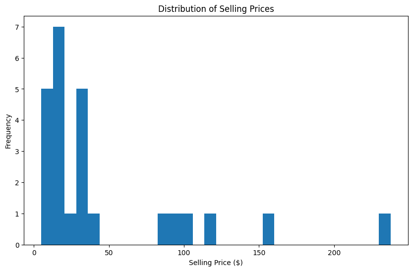

```python
#Sdata presents 25 rows of dataset we use to visualize
sdata=df.head(25)
sdata['Selling Price'] = sdata['Selling Price'].replace('[\$,]', '', regex=True).astype(float)

# Visualization 1: Distribution of Selling Prices
plt.figure(figsize=(10, 6))
plt.hist(sdata['Selling Price'], bins=30)
plt.title("Distribution of Selling Prices")
plt.xlabel("Selling Price ($)")
plt.ylabel("Frequency")
plt.show()
```

A count plot is generated to visualize the number of products by category, with the categories ordered by their frequency.

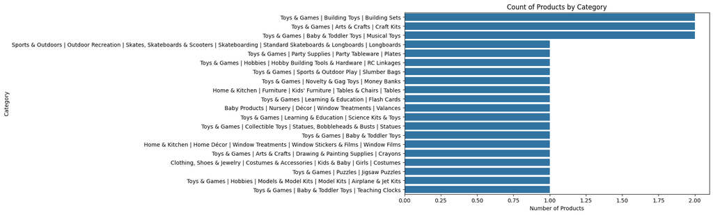

```python
# Visualization 2: Count of products by Category
plt.figure(figsize=(10, 6))
sns.countplot(y=sdata['Category'], order=sdata['Category'].value_counts().index)
plt.title('Count of Products by Category')
plt.xlabel('Number of Products')
plt.ylabel('Category')
plt.show()
```

A boxplot is created to visualize the distribution of selling prices across different product categories.

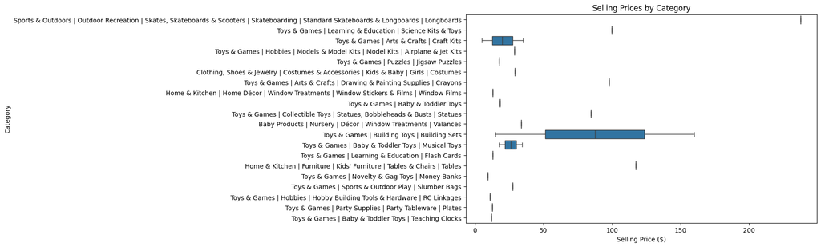

```python
# Visualization 3: Boxplot of Selling Prices by Category
plt.figure(figsize=(10, 6))
sns.boxplot(x='Selling Price', y='Category', data=sdata)
plt.title('Selling Prices by Category')
plt.xlabel('Selling Price ($)')
plt.ylabel('Category')
plt.show()
```

A pie chart is generated to show the percentage distribution of products by category, with the sizes of the slices based on the count of products in each category.

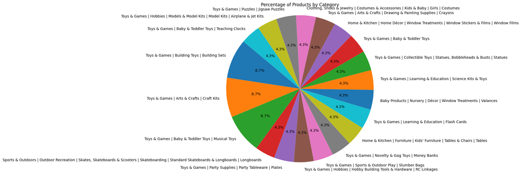

```python
# Visualization 4: Pie chart of product categories
category_counts = sdata['Category'].value_counts()
plt.figure(figsize=(8, 8))
plt.pie(category_counts, labels=category_counts.index, autopct='%1.1f%%', startangle=140)
plt.title('Percentage of Products by Category')
plt.axis('equal')
plt.show()
```

The DataFrame is saved to a CSV file named `newdataset.csv` without including the index column.

```python
df.to_csv('newdataset.csv', index=False)
```

A function is defined to clean the 'Selling Price' column by handling ranges (e.g., "74.99 - 249.99"), normalizing spaces, and removing non-numeric characters. The function converts values to floats, applies the cleaning process to the 'Selling Price' column, and displays the first few cleaned values.

```python
# Define a function to clean the 'Selling Price' column
def clean_selling_price(price):
    if isinstance(price, str):
        # Normalize spaces and handle multiple decimals
        price = re.sub(r'\s+', ' ', price)  # Replace multiple spaces with a single space
        price = re.sub(r'[^0-9.\s-]', '', price)  # Remove non-numeric characters except for '.' and '-'

        # If there's a range like '74.99 - 249.99', take the average
        if ' - ' in price:
            prices = price.split(' - ')
            return np.mean([float(p.strip()) for p in prices if p.strip().replace('.', '', 1).isdigit()])

        # If it's a single value, remove the dollar sign (if any) and convert to float
        try:
            return float(price.strip())
        except ValueError:
            return np.nan  # Return NaN for any values that can't be converted
    return np.nan  # Return NaN for non-string values

# Apply the function to the 'Selling Price' column
df['Selling Price'] = df['Selling Price'].apply(clean_selling_price)

# Check the cleaned data
print(df['Selling Price'].head())
```

```
0    237.68
1     99.95
2     34.99
3     28.91
4     17.49
Name: Selling Price, dtype: float64
```

A histogram is plotted to visualize the distribution of selling prices, with a kernel density estimate (KDE) overlayed for smoothness, using Seaborn and Matplotlib libraries. The x-axis represents the selling price in dollars, and the y-axis shows the frequency of those prices.

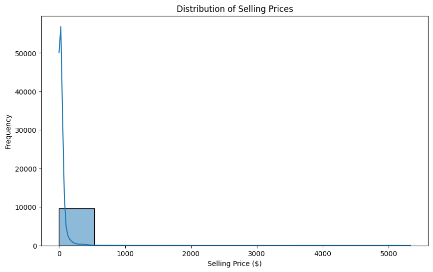

```python
# Now, let's visualize the data
import matplotlib.pyplot as plt
import seaborn as sns

# Visualization 1: Distribution of Selling Prices
plt.figure(figsize=(10, 6))
sns.histplot(df['Selling Price'], bins=10, kde=True)
plt.title('Distribution of Selling Prices')
plt.xlabel('Selling Price ($)')
plt.ylabel('Frequency')
plt.show()
```

A count plot is created to visualize the number of products in each category, with the categories ordered by their frequency. The x-axis represents the number of products, and the y-axis lists the different categories.

[figure not shown]

```python
# Visualization 2: Count of Products by Category
plt.figure(figsize=(10, 6))
sns.countplot(y=df['Category'], order=df['Category'].value_counts().index)
plt.title('Count of Products by Category')
plt.xlabel('Number of Products')
plt.ylabel('Category')
plt.show()
```

A boxplot is created to visualize the distribution of selling prices across different product categories. The x-axis represents the selling price in dollars, and the y-axis shows the product categories.

[figure not shown]

```python
# Visualization 3: Boxplot of Selling Prices by Category
plt.figure(figsize=(10, 6))
sns.boxplot(x='Selling Price', y='Category', data=df)
plt.title('Selling Prices by Category')
plt.xlabel('Selling Price ($)')
plt.ylabel('Category')
plt.show()
```

A pie chart is generated to display the percentage distribution of products by category, with each slice representing a category's proportion relative to the total number of products. The pie chart uses equal axis scaling to ensure the slices are proportional.

[figure not shown]

```python
# Optional: Pie chart of product categories (if there are few unique categories)
category_counts = df['Category'].value_counts()
plt.figure(figsize=(8, 8))
plt.pie(category_counts, labels=category_counts.index, autopct='%1.1f%%', startangle=140)
plt.title('Percentage of Products by Category')
plt.axis('equal')
plt.show()
```

**Hypothesis Testing for Price Differences Between Two Categories**

**T-test:**

Objective: Testing if there’s a significant difference in the average selling price between two chosen categories.

```
Toys & Games count: 6516
Home & Kitchen count: 687
T-statistic: -9.480003678624673, P-value: 3.3787405070442648e-21
```

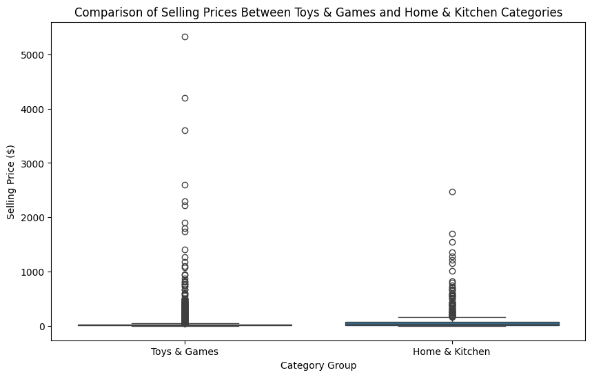

```python
import pandas as pd
from scipy import stats
import numpy as np
import matplotlib.pyplot as plt
import seaborn as sns

# Ensure 'Selling Price' is numeric and clean the data
df['Selling Price'] = pd.to_numeric(df['Selling Price'], errors='coerce')
df = df.dropna(subset=['Selling Price'])

# Fill missing values in the 'Category' column with a placeholder
df['Category'] = df['Category'].fillna('Unknown')

# Group similar categories together into broader categories
df['Category_Group'] = df['Category'].apply(lambda x: 'Toys & Games' if 'Toys & Games' in x else ('Home & Kitchen' if 'Home & Kitchen' in x else 'Other'))

# Filter data to only include the two main groups for comparison
category_a = df[df['Category_Group'] == 'Toys & Games']['Selling Price'].dropna()
category_b = df[df['Category_Group'] == 'Home & Kitchen']['Selling Price'].dropna()

# Check data counts to ensure sufficient data for each group
print("Toys & Games count:", len(category_a))
print("Home & Kitchen count:", len(category_b))

# Perform the t-test if data is sufficient
if len(category_a) > 1 and len(category_b) > 1:
    # Perform a t-test
    t_stat, p_value = stats.ttest_ind(category_a, category_b, nan_policy='omit')
    print(f"T-statistic: {t_stat}, P-value: {p_value}")

    # If the t-test returns NaN, use Mann-Whitney U test as an alternative
    if np.isnan(t_stat) or np.isnan(p_value):
        print("T-test returned NaN. Trying Mann-Whitney U test instead.")
        u_stat, p_value = stats.mannwhitneyu(category_a, category_b, alternative='two-sided')
        print(f"U-statistic: {u_stat}, P-value: {p_value}")

    # Plot the boxplot for visual comparison between groups
    plt.figure(figsize=(10, 6))
    sns.boxplot(x='Category_Group', y='Selling Price', data=df[df['Category_Group'].isin(['Toys & Games', 'Home & Kitchen'])])
    plt.title("Comparison of Selling Prices Between Toys & Games and Home & Kitchen Categories")
    plt.xlabel("Category Group")
    plt.ylabel("Selling Price ($)")
    plt.show()
else:
    print("Not enough data in one or both groups for a meaningful test.")
```